# ML Basics - Árvore de Decisão - Modelo_T0001

Rafael Vinicius Curiel

11/02/2022

## Pacotes e comandos

Carregamento dos pacotes

```r
pacotes <- c("titanic", "tidyverse", "rpart", "rpart.plot", "gtools", "Rmisc", "scales", "caret", "plotROC", "egg")
base::sapply(pacotes, require, character = T)
```

```
##    titanic  tidyverse      rpart rpart.plot     gtools      Rmisc     scales
##       TRUE       TRUE       TRUE       TRUE       TRUE       TRUE       TRUE
##      caret    plotROC        egg
##       TRUE       TRUE       TRUE
```

### Carregamento do objeto

Carregamento da base de dados e atribuindo a uma base temporária:

```r
base::load("D:/datasets/titanic.RData")
titanic_temp<- titanic
titanic_temp %>% head
```

```
##   Survived Pclass    Sex      Age SibSp Parch    Fare Embarked
## 1        N      3   male 22.00000     1     0  7.2500        S
## 2        Y      1 female 38.00000     1     0 71.2833        C
## 3        Y      3 female 26.00000     0     0  7.9250        S
## 4        Y      1 female 35.00000     1     0 53.1000        S
## 5        N      3   male 35.00000     0     0  8.0500        S
## 6        N      3   male 29.69912     0     0  8.4583        Q
```

## Exploração

Criação de nova coluna binária para sobrevivência:

```r
titanic_temp$survived <- base::as.integer(titanic$Survived=="Y")
```

Criação de uma função para análise descritiva:

```r
descritiva <- function(var){
  tgc <- Rmisc::summarySE(titanic_temp, measurevar="survived", groupvars=c(var))

  ggplot(tgc) +
    geom_bar(aes(x=tgc[,var], weight=N/891, fill=as.factor(tgc[,var]))) +
    geom_errorbar(aes(x=tgc[,var], y=survived, ymin=survived-se, ymax=survived+se, colour='1'), width=.1) +
    geom_point(aes(x=tgc[,var], y=survived, colour='1', group='1')) +
    geom_line(aes(x=tgc[,var], y=survived, colour='1', group='1')) +
    theme(panel.background = element_rect(fill = "white", colour = "grey", linetype = "solid"),
          panel.grid.major = element_line(size = 0.15, linetype = 'solid', colour = "grey")) +
    theme(legend.position = "none") +
    xlab(var) + ylab("Taxa de sobreviventes") +
    scale_y_continuous(sec.axis = sec_axis(~.*891, name = "Frequencia"), labels = scales::percent)
}
```

Visualização gráfica dos sobreviventes por sexo:

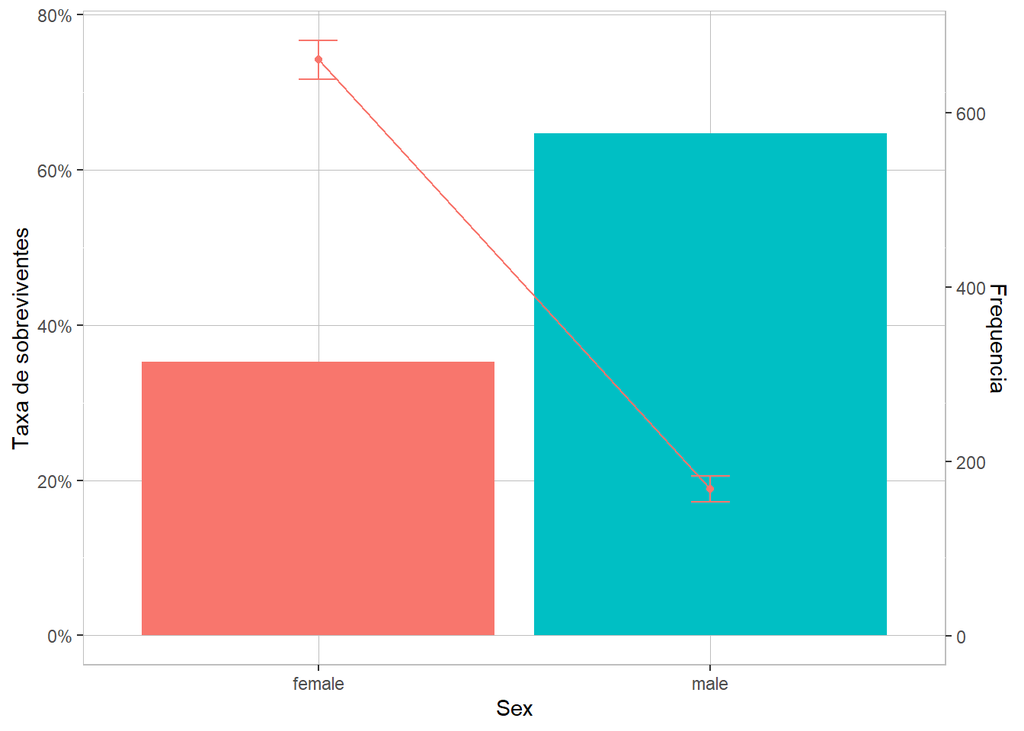

```r
descritiva("Sex")
```

Visualização gráfica dos sobreviventes por classe:

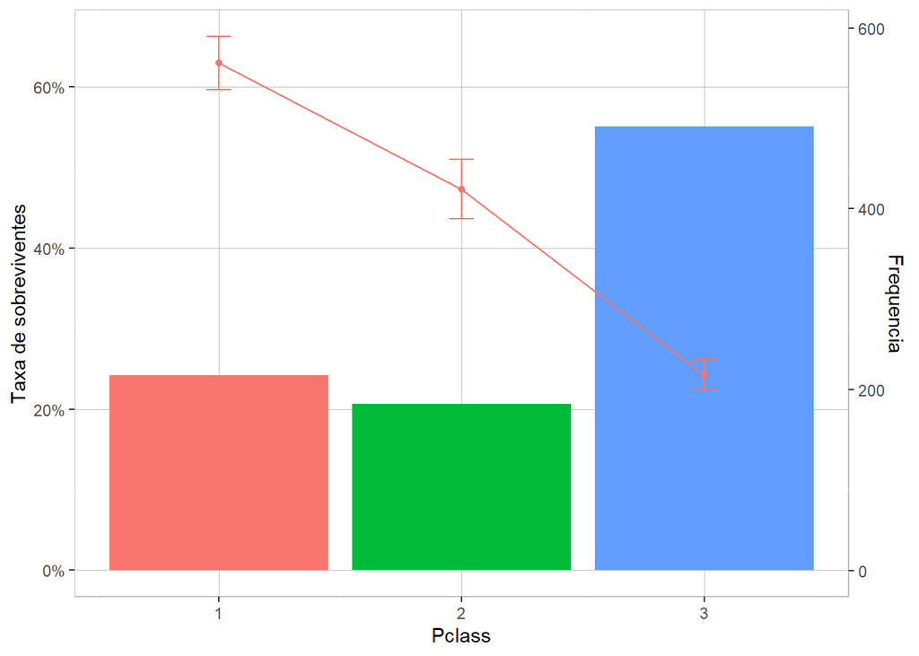

```r
descritiva("Pclass")
```

Visualização gráfica dos sobreviventes por embarque:

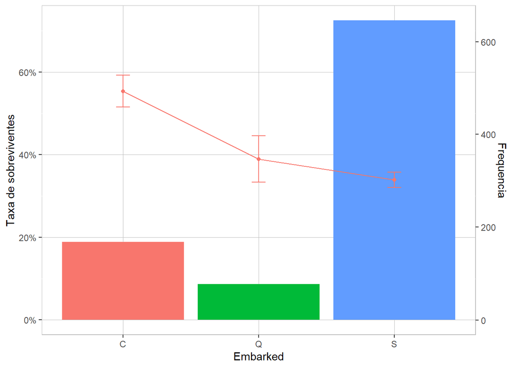

```r
descritiva("Embarked")
```

Visualização gráfica dos sobreviventes com irmãos/cônjuge:

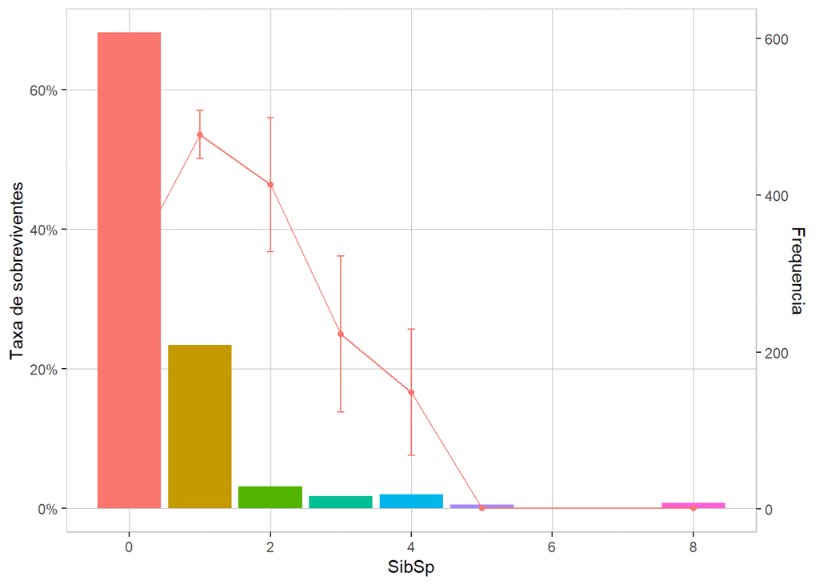

```r
descritiva("SibSp")
```

Visualização gráfica dos sobreviventes com pais/filhos:

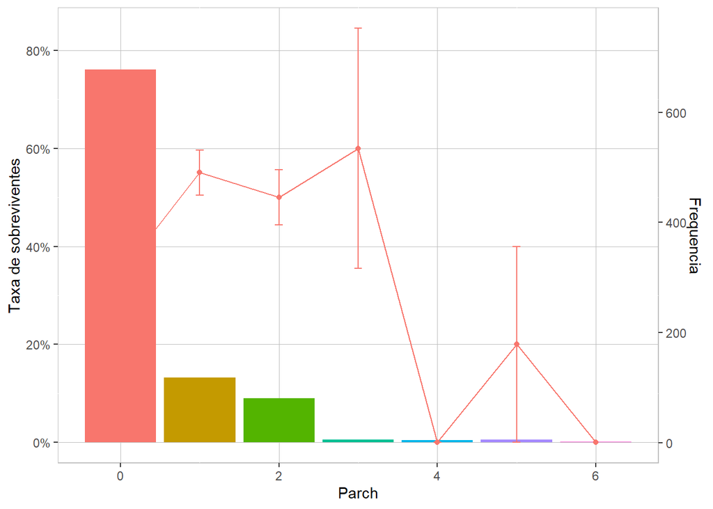

```r
descritiva("Parch")
```

Visualização gráfica dos sobreviventes por idade (categorizada):

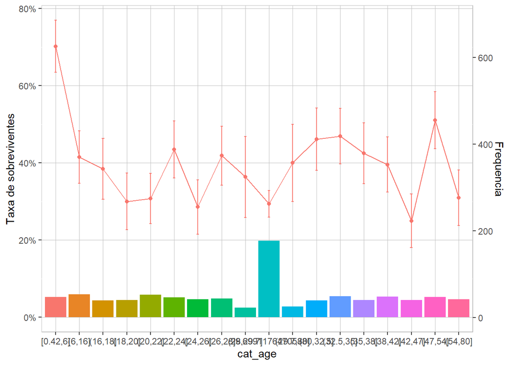

```r
titanic_temp$cat_age <- gtools::quantcut(titanic$Age, 20)
descritiva("cat_age")
```

Visualização gráfica dos sobreviventes pelo preço do bilhete (categorizada):

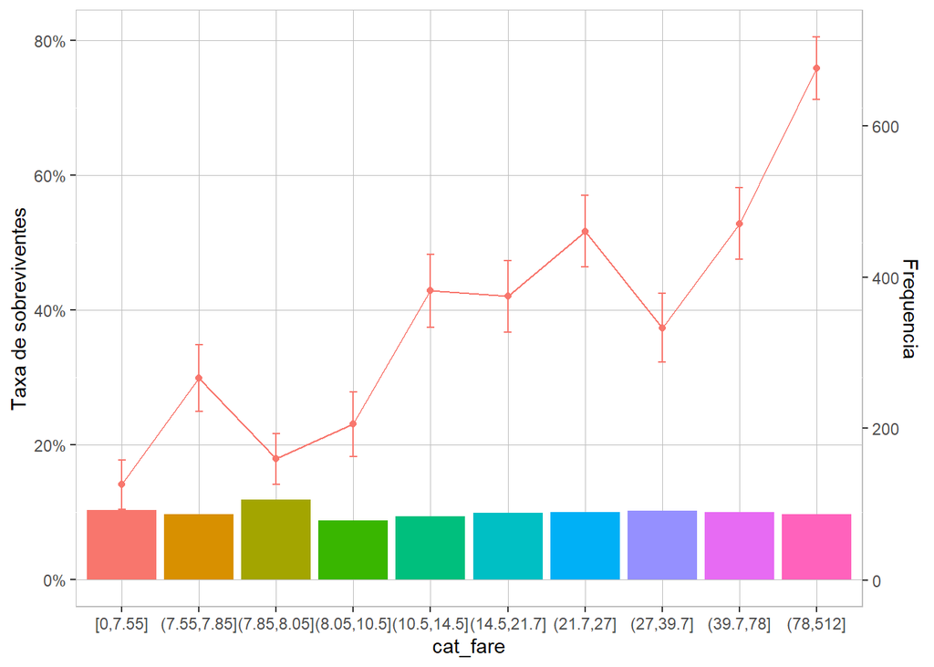

```r
titanic_temp$cat_fare <- gtools::quantcut(titanic$Fare, 10)
descritiva("cat_fare")
```

## Modelo 1

Árvore de Decisão M1:

```r
m1_arvore <- rpart::rpart(Survived ~ Pclass + Sex + Age + SibSp + Parch + Fare + Embarked,
                data=titanic,
                parms = list(split = 'gini'),
                method='class'
)
```

### Visualização Árvore M1

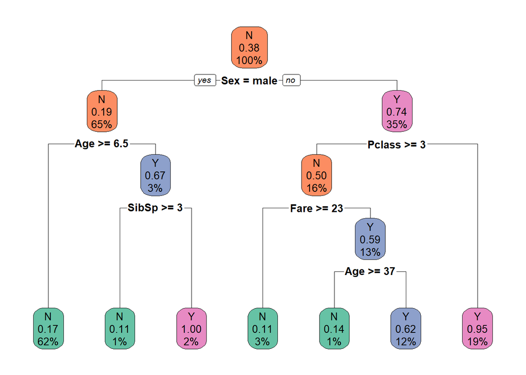

```r
palete = scales::brewer_pal(palette = "Set2")(4)
rpart.plot::rpart.plot(m1_arvore,
                       box.palette = palete)
```

### Avaliação M1

Probabilidade e Classificação:

```r
m1_probabilidade = stats::predict(m1_arvore, titanic)
m1_classificacao = m1_probabilidade[,2]>.5
```

Matriz de Confusão:

```r
m1_confusao <- table(m1_classificacao, titanic$Survived)
m1_confusao
```

```
##
## m1_classificacao   N   Y
##            FALSE 498  98
##            TRUE   51 244
```

Acurácia M1:

```r
m1_acuracia <- ((m1_confusao[1,1] + m1_confusao[2,2])/ sum(m1_confusao))
sprintf('Acurácia M1: %s ', percent(m1_acuracia))
```

```
## [1] "Acurácia M1: 83% "
```

## Modelo 2 - Cross Validation

Base de Treino e Teste:

```r
set.seed(123)

m2_base <- stats::runif(dim(titanic)[1])>.25

m2_treino <- titanic[m2_base,]
m2_teste  <- titanic[!m2_base,]
```

Árvore de Decisão M2:

```r
set.seed(123)
m2_arvore <- rpart::rpart(Survived ~ Pclass + Sex + Age + SibSp + Parch + Fare + Embarked,
                data=m2_treino,
                method='class',
                xval=5,
                control = rpart.control(cp = 0,
                                        minsplit = 1,
                                        maxdepth = 30)
)
```

### Visualização Árvore M2

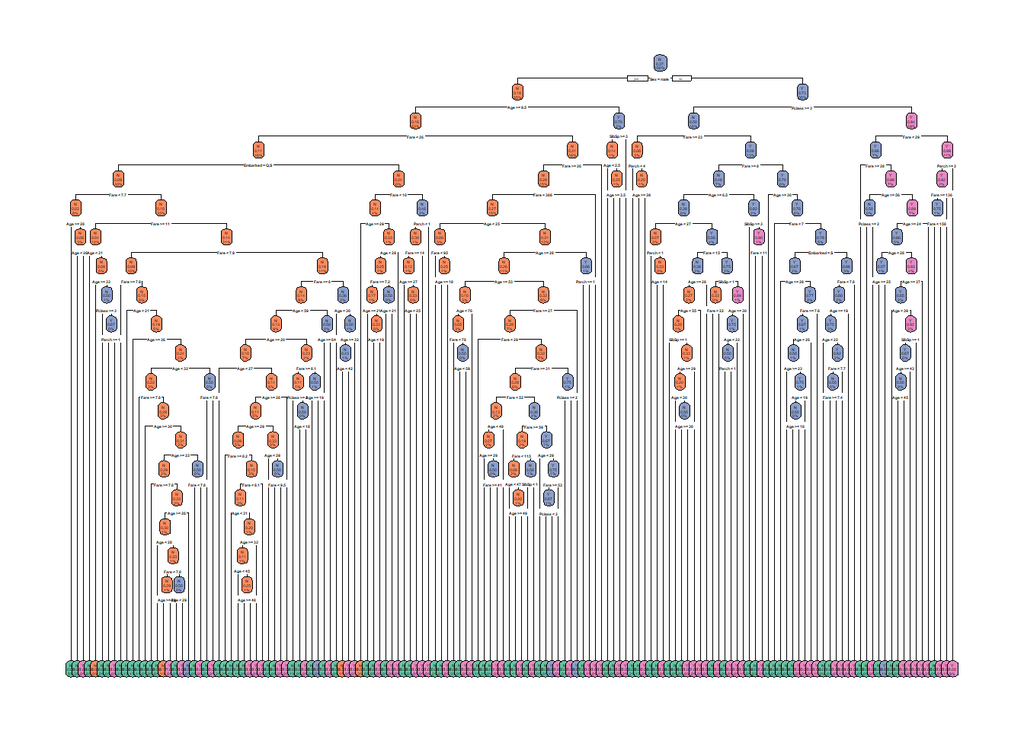

```r
palete = scales::brewer_pal(palette = "Set2")(4)
rpart.plot::rpart.plot(m2_arvore,
                       box.palette = palete)
```

### Treino M2

Avaliação Treino M2:

```r
m2_treino_probabilidade = stats::predict(m2_arvore, m2_treino)
m2_treino_classificacao = base::factor(ifelse(m2_treino_probabilidade[,2]>.5, "Y", "N"))

m2_confusao <- base::table(m2_treino_classificacao, m2_treino$Survived)
m2_acuracia <- (m2_confusao[1,1]+m2_confusao[2,2])/nrow(m2_treino)
base::sprintf('Acurácia Treino M2: %s ', percent(m2_acuracia))
```

```
## [1] "Acurácia Treino M2: 98% "
```

Avaliação Teste M2:

```r
m2_teste_probabilidade = stats::predict(m2_arvore, m2_teste)
m2_teste_classificacao = base::factor(ifelse(m2_teste_probabilidade[,2]>.5, "Y", "N"))

m2_confusao <- table(m2_teste_classificacao, m2_teste$Survived)
m2_acuracia <- (m2_confusao[1,1]+m2_confusao[2,2])/nrow(m2_teste)
sprintf('Acurácia Teste M2: %s ', percent(m2_acuracia))
```

```
## [1] "Acurácia Teste M2: 81% "
```

## Curva ROC - Receiver Operating Characteristic Curve

### Base Treino

Criação do DataFrame:

```r
m2_treino_avaliacao <- base::data.frame(obs=m2_treino$Survived,
                         pred=m2_treino_classificacao,
                         Y = m2_treino_probabilidade[,2],
                         N = 1-m2_treino_probabilidade[,2]
                         )
```

Cálculo da Perfomance (ROC, Sensitividade e Especificidade):

```r
caret::twoClassSummary(m2_treino_avaliacao, lev=levels(m2_treino_avaliacao$obs))
```

```
##       ROC      Sens      Spec
## 0.9984630 0.9832936 0.9800000
```

Visualização da Curva ROC:

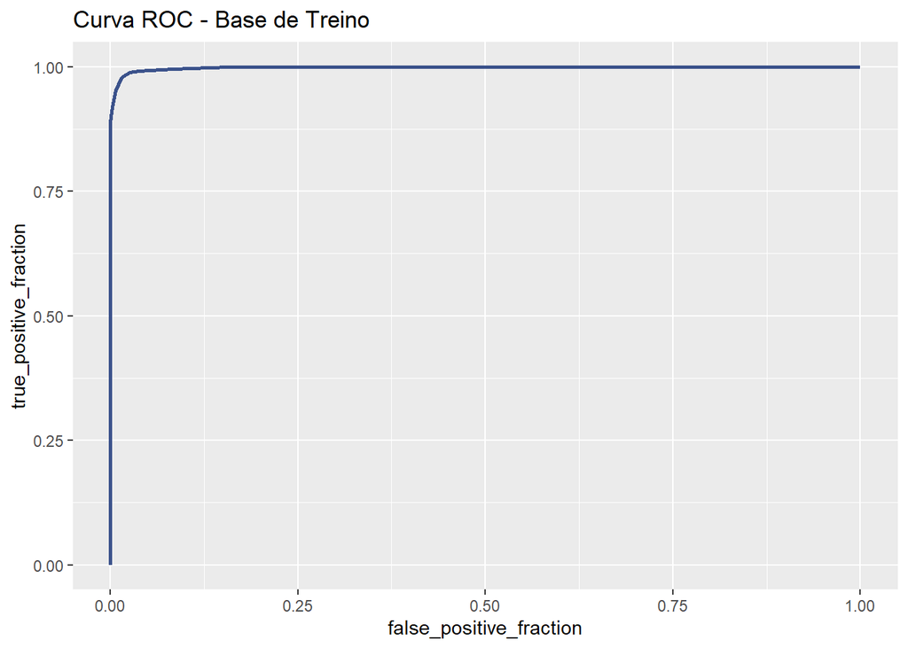

```r
m2_treino_CurvaROC <- ggplot2::ggplot(m2_treino_avaliacao, aes(d = obs, m = Y, colour='1')) +
  plotROC::geom_roc(n.cuts = 0) +
  scale_color_viridis_d(direction = -1, begin=0, end=.25) +
  theme(legend.position = "none") +
  ggtitle("Curva ROC - Base de Treino")

m2_treino_CurvaROC
```

### Base Teste

```r
m2_teste_avaliacao <- data.frame(obs=m2_teste$Survived,
                         pred=m2_teste_classificacao,
                         Y = m2_teste_probabilidade[,2],
                         N = 1-m2_teste_probabilidade[,2]
                         )
```

Cálculo da Perfomance (ROC, Sensitividade e Especificidade):

```r
caret::twoClassSummary(m2_teste_avaliacao, lev=levels(m2_teste_avaliacao$obs))
```

```
##       ROC      Sens      Spec
## 0.7778010 0.8769231 0.7065217
```

Visualização da Curva ROC

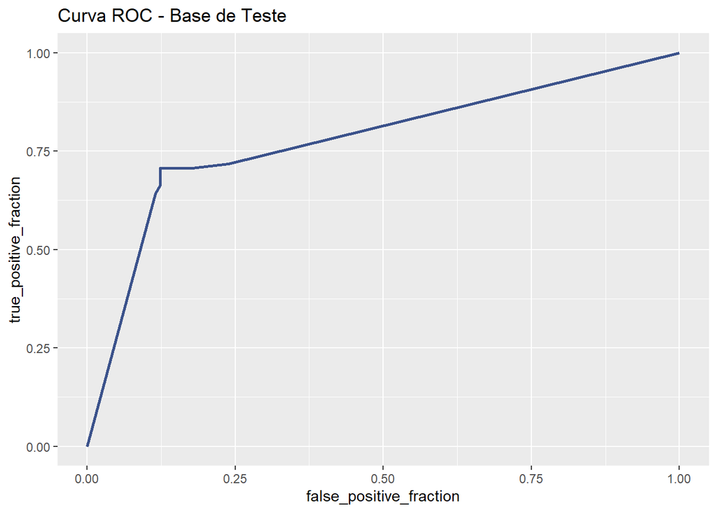

```r
m2_teste_CurvaROC <- ggplot2::ggplot(m2_teste_avaliacao, aes(d = obs, m = Y, colour='1')) +
  plotROC::geom_roc(n.cuts = 0) +
  scale_color_viridis_d(direction = -1, begin=0, end=.25) +
  theme(legend.position = "none") +
  ggtitle("Curva ROC - Base de Teste")

m2_teste_CurvaROC
```

Visualização Conjunta dos Resultados

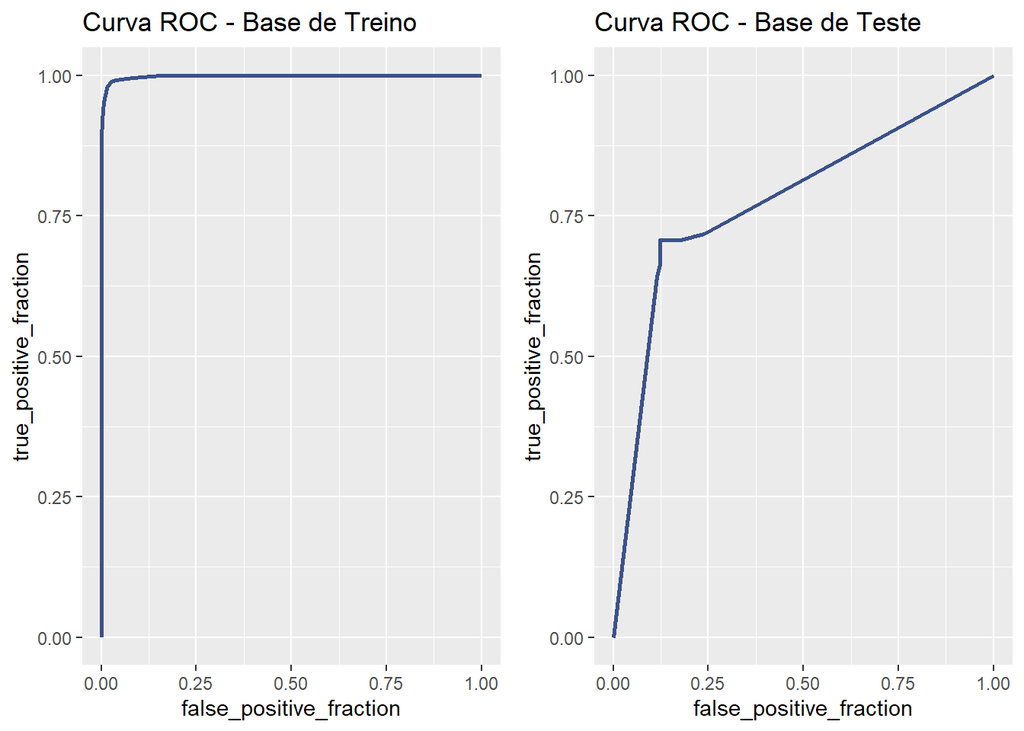

```r
egg::ggarrange(m2_treino_CurvaROC, m2_teste_CurvaROC, ncol = 2)
```

## Prunning - Grid Search

### Definição do CP (Complexity Parameter) Mínimo

Possibilidades de CP

```r
tab_cp <- rpart::printcp(m2_arvore)
```

```
##
## Classification tree:
## rpart::rpart(formula = Survived ~ Pclass + Sex + Age + SibSp +
##     Parch + Fare + Embarked, data = m2_treino, method = "class",
##     control = rpart.control(cp = 0, minsplit = 1, maxdepth = 30),
##     xval = 5)
##
## Variables actually used in tree construction:
## [1] Age      Embarked Fare     Parch    Pclass   Sex      SibSp
##
## Root node error: 250/669 = 0.37369
##
## n= 669
##
##           CP nsplit rel error xerror     xstd
## 1  0.4320000      0     1.000  1.000 0.050052
## 2  0.0320000      1     0.568  0.568 0.042305
## 3  0.0300000      2     0.536  0.556 0.041975
## 4  0.0200000      4     0.476  0.524 0.041056
## 5  0.0180000      5     0.456  0.528 0.041174
## 6  0.0120000      7     0.420  0.500 0.040328
## 7  0.0080000     10     0.384  0.496 0.040203
## 8  0.0040000     16     0.332  0.484 0.039823
## 9  0.0026667     41     0.224  0.536 0.041407
## 10 0.0020000     44     0.216  0.540 0.041523
## 11 0.0016000     83     0.136  0.588 0.042839
## 12 0.0013333    114     0.084  0.640 0.044133
## 13 0.0008000    128     0.064  0.664 0.044687
## 14 0.0000000    143     0.048  0.668 0.044777
```

```r
tab_cp
```

```
##             CP nsplit rel error xerror       xstd
## 1  0.432000000      0     1.000  1.000 0.05005229
## 2  0.032000000      1     0.568  0.568 0.04230546
## 3  0.030000000      2     0.536  0.556 0.04197515
## 4  0.020000000      4     0.476  0.524 0.04105572
## 5  0.018000000      5     0.456  0.528 0.04117381
## 6  0.012000000      7     0.420  0.500 0.04032751
## 7  0.008000000     10     0.384  0.496 0.04020277
## 8  0.004000000     16     0.332  0.484 0.03982263
## 9  0.002666667     41     0.224  0.536 0.04140723
## 10 0.002000000     44     0.216  0.540 0.04152259
## 11 0.001600000     83     0.136  0.588 0.04283915
## 12 0.001333333    114     0.084  0.640 0.04413324
## 13 0.000800000    128     0.064  0.664 0.04468739
## 14 0.000000000    143     0.048  0.668 0.04477721
```

Plotagem dos CP’s:

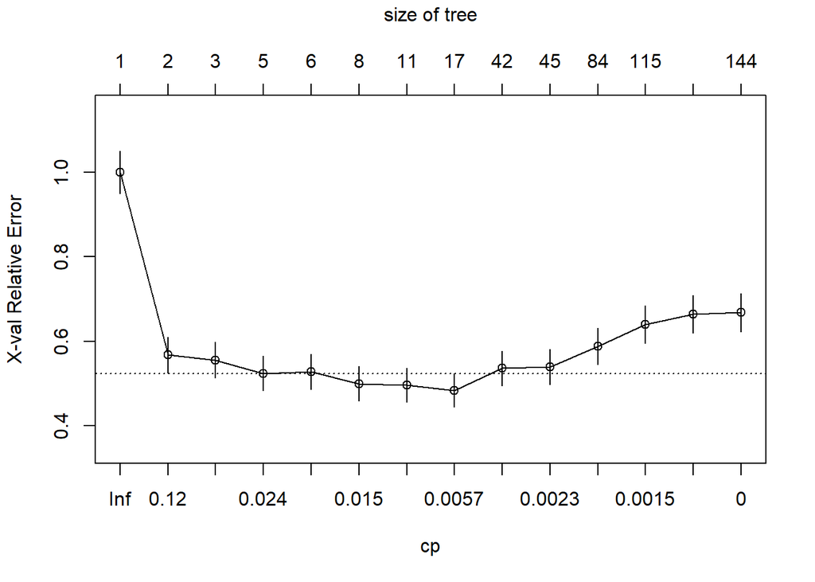

```r
rpart::plotcp(m2_arvore)
```

Definição do CP mínimo:

```r
tab_cp[which.min(tab_cp[,'xerror']),]
```

```
##          CP      nsplit   rel error      xerror        xstd
##  0.00400000 16.00000000  0.33200000  0.48400000  0.03982263
```

```r
cp_min <- tab_cp[which.min(tab_cp[,'xerror']),'CP']
sprintf('CP mínimo %.5f ', cp_min)
```

```
## [1] "CP mínimo 0.00400 "
```

### Decision Tree

Árvore com CP Mínimo:

```r
set.seed(1)
m2_arvore_poda <- rpart::rpart(Survived ~ Pclass + Sex + Age + SibSp + Parch + Fare + Embarked,
                            data=m2_treino,
                            method='class',
                            xval=0,
                            control = rpart.control(cp = cp_min,
                                                    minsplit = 1,
                                                    maxdepth = 30)
)
```

### Visualização Árvore M2 Podada

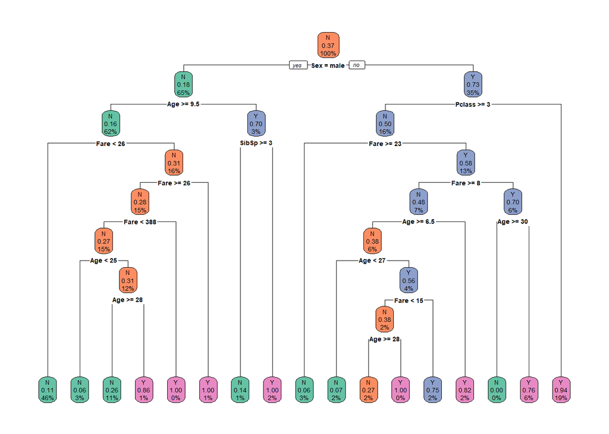

```r
palete = scales::brewer_pal(palette = "Set2")(4)
rpart.plot::rpart.plot(m2_arvore_poda,
                       box.palette = palete)
```

### Treino

Definição do Treino:

```r
m2_2_treino_probabilidade = stats::predict(m2_arvore_poda, m2_treino)
m2_2_treino_classificacao = base::factor(ifelse(m2_2_treino_probabilidade[,2]>.5, "Y", "N"))
```

Avaliação do Treino:

```r
m2_2_treino_avaliacao <- data.frame(obs=m2_treino$Survived,
                          pred=m2_2_treino_classificacao,
                          Y = m2_2_treino_probabilidade[,2],
                          N = 1-m2_2_treino_probabilidade[,2]
)
```

Cálculo da Perfomance (ROC, Sensitividade e Especificidade):

```r
caret::twoClassSummary(m2_2_treino_avaliacao, lev=levels(m2_2_treino_avaliacao$obs))
```

```
##       ROC      Sens      Spec
## 0.8909690 0.9451074 0.7600000
```

Curva ROC:

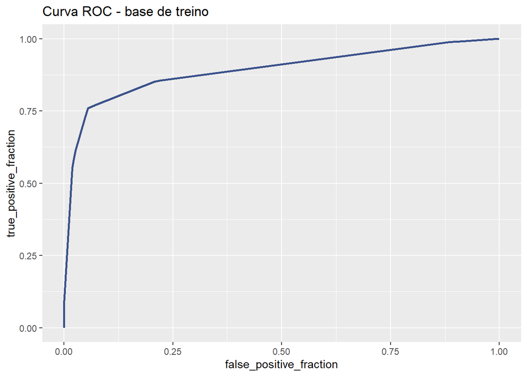

```r
m2_2_treino_CurvaROC <- ggplot2::ggplot(m2_2_treino_avaliacao, aes(d = obs, m = Y, colour='1')) +
  plotROC::geom_roc(n.cuts = 0) +
  scale_color_viridis_d(direction = -1, begin=0, end=.25) +
  theme(legend.position = "none") +
  ggtitle("Curva ROC - base de treino")

m2_2_treino_CurvaROC
```

### Teste

Definição do Teste:

```r
m2_2_teste_probabilidade = stats::predict(m2_arvore_poda, m2_teste)
m2_2_teste_classificacao = base::factor(ifelse(m2_2_teste_probabilidade[,2]>.5, "Y", "N"))
```

Avaliação do Treino:

```r
m2_2_teste_avaliacao <- data.frame(obs=m2_teste$Survived,
                         pred=m2_2_teste_classificacao,
                         Y = m2_2_teste_probabilidade[,2],
                         N = 1-m2_2_teste_probabilidade[,2]
)
```

Cálculo da Perfomance (ROC, Sensitividade e Especificidade):

```r
caret::twoClassSummary(m2_2_teste_avaliacao, lev=levels(m2_2_teste_avaliacao$obs))
```

```
##       ROC      Sens      Spec
## 0.8130017 0.9538462 0.6521739
```

Curva ROC:

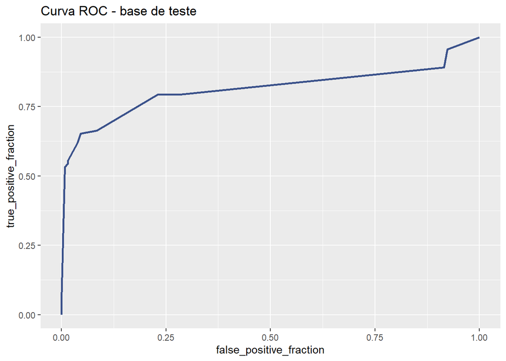

```r
m2_2_teste_CurvaROC <- ggplot(m2_2_teste_avaliacao, aes(d = obs, m = Y, colour='a')) +
  plotROC::geom_roc(n.cuts = 0) +
  scale_color_viridis_d(direction = -1, begin=0, end=.25) +
  theme(legend.position = "none") +
  ggtitle("Curva ROC - base de teste")

m2_2_teste_CurvaROC
```

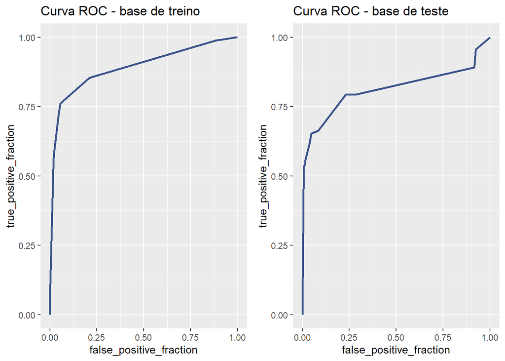

```r
egg::ggarrange(m2_2_treino_CurvaROC, m2_2_teste_CurvaROC, ncol = 2)
```